## Loading and preprocessing the data

Show any code that is needed to

Load the data (i.e. read.csv())

Process/transform the data (if necessary) into a format suitable for your analysis

```r
     fileUrl <- "https://d396qusza40orc.cloudfront.net/repdata%2Fdata%2Factivity.zip?accessType=DOWNLOAD"
     download.file(fileUrl, destfile = "/Users/administrador/Specialization/Activity_monitoring_data.zip",
     method = "curl")
```

unzip the file

```r
     unzip("/Users/administrador/Specialization/Activity_monitoring_data.zip")
```

Read the file

```r
     activity <- read.table("/Users/administrador/Specialization/activity.csv", sep = ",", header = TRUE)
```

Show the head file

```r
     head(activity)
```

```
##   steps       date interval
## 1    NA 2012-10-01        0
## 2    NA 2012-10-01        5
## 3    NA 2012-10-01       10
## 4    NA 2012-10-01       15
## 5    NA 2012-10-01       20
## 6    NA 2012-10-01       25
```

Stream the databases

```r
     str(activity)
```

```
## 'data.frame':    17568 obs. of  3 variables:
##  $ steps   : int  NA NA NA NA NA NA NA NA NA NA ...
##  $ date    : Factor w/ 61 levels "2012-10-01","2012-10-02",..: 1 1 1 1 1 1 1 1 1 1 ...
##  $ interval: int  0 5 10 15 20 25 30 35 40 45 ...
```

## What is mean total number of steps taken per day?

The *xtabs* and *mean* function can be used to determine the mean total number of steps taken per day

```r
     totalNumberSteps <- xtabs(steps ~ date,activity)

     mean(totalNumberSteps)
```

```
## [1] 9354
```

Other way Just to check the total number of steps per day are being calculated correctly, we sum the steps for days explicitly and dividing that number by the total number of days.

```r
      sum(activity$steps, na.rm=TRUE)/length(levels(activity$date))
```

```
## [1] 9354
```

## What is the average daily activity pattern?

The dayli activity pattern is defined by the interval

```r
     average <- xtabs(activity$steps ~ activity$interval)/xtabs(~ activity$interval)
     summary(as.numeric(average))
```

```
##    Min. 1st Qu.  Median    Mean 3rd Qu.    Max.
##    0.00    2.16   29.60   32.50   45.90  179.00
```

Plot

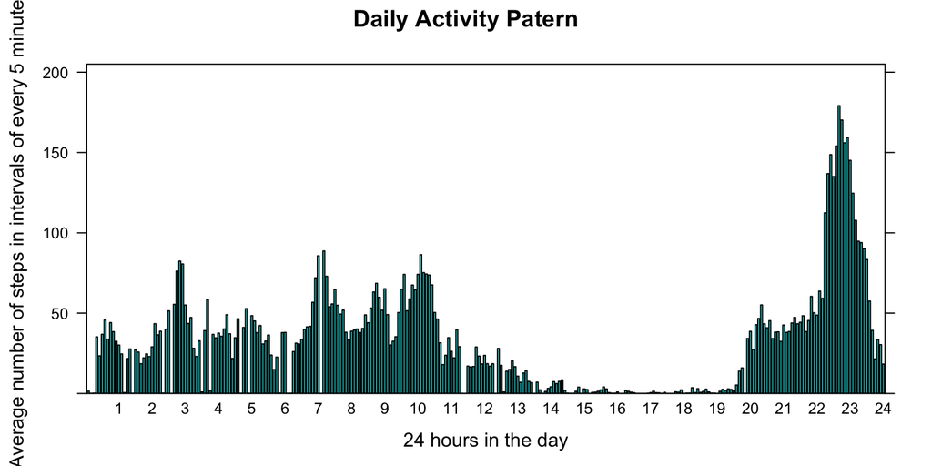

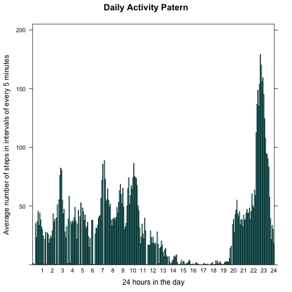

Saving the file

## Imputing missing values

Therefore, you should observe the distribution of missing data per interval.

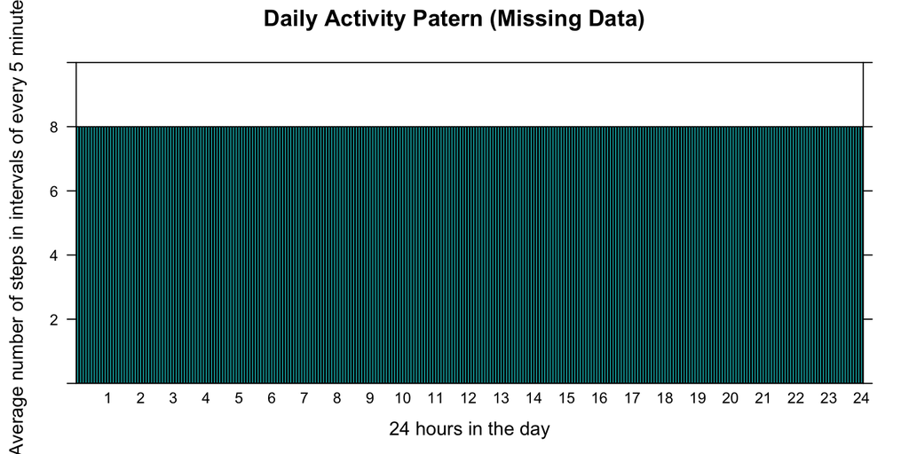

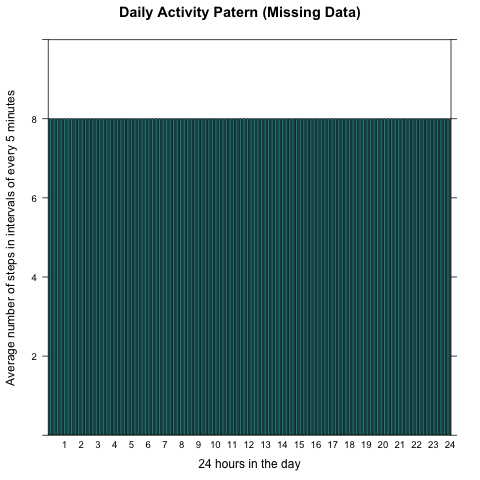

Saving the file

If needed

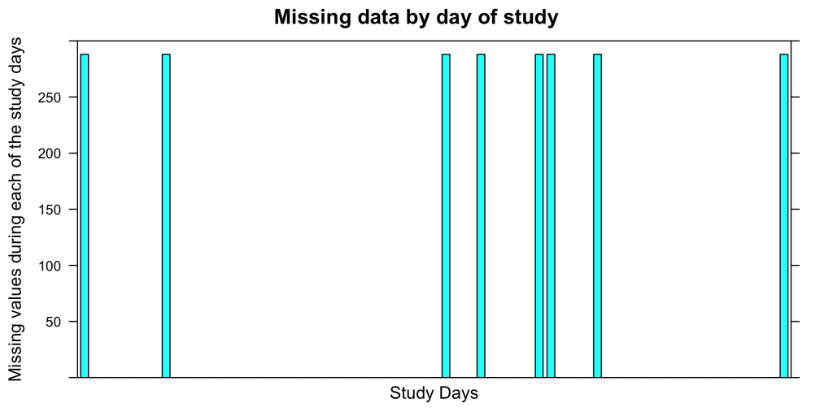

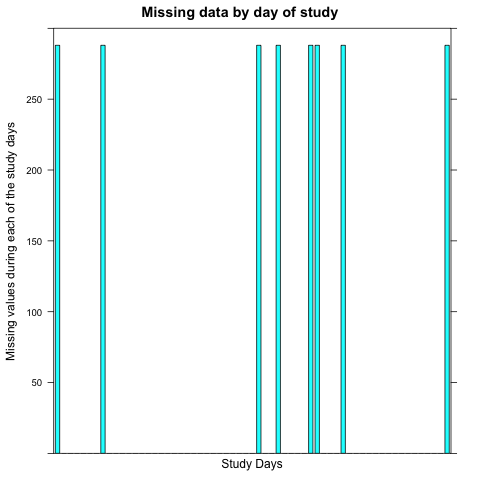

Saving the file

The total days of study was 61, but data from 8 of those days were lost, to find the position of the missing data and their corresponding dates of the procedure should be as follows:

```r
activity$wday <- factor(strptime(activity$date,"%Y-%m-%d")$wday,
labels=c("Sun","Mon","Tue","Wed","Thu","Fri","Sat"))
missingDays <- unique(subset(within(activity,{NAs <- is.na(steps)}),select = c(date,wday,NAs)))
subset(missingDays,NAs,select=-NAs)
```

```
##             date wday
## 1     2012-10-01  Mon
## 2017  2012-10-08  Mon
## 8929  2012-11-01  Thu
## 9793  2012-11-04  Sun
## 11233 2012-11-09  Fri
## 11521 2012-11-10  Sat
## 12673 2012-11-14  Wed
## 17281 2012-11-30  Fri
```

### Are there differences in activity patterns between weekdays and weekends?

The differences in activity patterns between weekdays and weekends, you can see if the activity is fused to the day (omitting missing values) and then determine the average number of steps per interval the days of the week and compared with weekends.

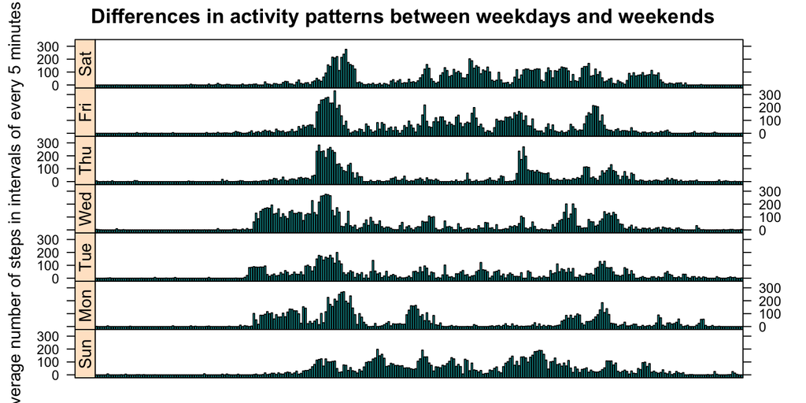

Saving the file

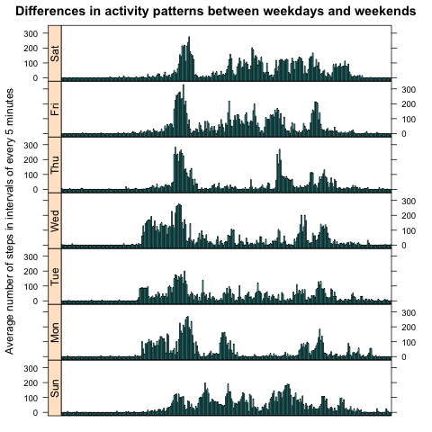

Saving the file